# Week 6 - Assignment Data Sets

## Project Overview

Here is a dataset that shows a simple 2-node network: the attendance of 18 Southern Women at 14 social events:

1. [Brief Description](http://vlado.fmf.uni-lj.si/pub/networks/data/ucinet/ucidata.htm#davis). Small “musty” datasets like that from this 1941 study have proven very valuable in testing and comparing new network algorithms.
2. [Dataset](http://vlado.fmf.uni-lj.si/pub/networks/data/Ucinet/davis.dat).
3. Python code to create dataset: https://networkx.github.io/documentation/stable/auto_examples/algorithms/plot_davis_club.html

What can you infer about the relationships between (1) the women, and (2) the social events?

## DAVIS SOUTHERN CLUB WOMEN

DESCRIPTION One 18×14 matrix, binary.

BACKGROUND These data were collected by Davis et al in the 1930s. They represent observed attendance at 14 social events by 18 Southern women. The result is a person-by-event matrix: cell (i,j) is 1 if person i attended social event j, and 0 otherwise.

REFERENCES

- Breiger R. (1974). The duality of persons and groups. Social Forces, 53, 181-190.
- Davis, A et al. (1941). Deep South. Chicago: University of Chicago Press.

## Import data

```python
import matplotlib.pyplot as plt
import networkx as nx
import networkx.algorithms.bipartite as bipartite

%matplotlib inline
plt.rcParams["figure.figsize"] = (12,10)

G = nx.davis_southern_women_graph()
women = G.graph['top']
clubs = G.graph['bottom']
```

```python
print("Biadjacency matrix")
print(bipartite.biadjacency_matrix(G, women, clubs))
```

```
Biadjacency matrix
  (0, 0)	1
  (0, 1)	1
  (0, 2)	1
  (0, 3)	1
  (0, 4)	1
  (0, 5)	1
  (0, 7)	1
  (0, 8)	1
  (1, 0)	1
  (1, 1)	1
  (1, 2)	1
  (1, 4)	1
  (1, 5)	1
  (1, 6)	1
  (1, 7)	1
  (2, 1)	1
  (2, 2)	1
  (2, 3)	1
  (2, 4)	1
  (2, 5)	1
  (2, 6)	1
  (2, 7)	1
  (2, 8)	1
  (3, 0)	1
  (3, 2)	1
  :	:
  (12, 7)	1
  (12, 8)	1
  (12, 9)	1
  (12, 11)	1
  (12, 12)	1
  (12, 13)	1
  (13, 5)	1
  (13, 6)	1
  (13, 8)	1
  (13, 9)	1
  (13, 10)	1
  (13, 11)	1
  (13, 12)	1
  (13, 13)	1
  (14, 6)	1
  (14, 7)	1
  (14, 9)	1
  (14, 10)	1
  (14, 11)	1
  (15, 7)	1
  (15, 8)	1
  (16, 8)	1
  (16, 10)	1
  (17, 8)	1
  (17, 10)	1
```

```python
# project bipartite graph onto women nodes
W = bipartite.projected_graph(G, women)
print('')
print("#Friends, Member")
for w in women:
    print('%d %s' % (W.degree(w), w))
```

```
#Friends, Member
17 Evelyn Jefferson
15 Laura Mandeville
17 Theresa Anderson
15 Brenda Rogers
11 Charlotte McDowd
15 Frances Anderson
15 Eleanor Nye
16 Pearl Oglethorpe
17 Ruth DeSand
17 Verne Sanderson
16 Myra Liddel
16 Katherina Rogers
17 Sylvia Avondale
17 Nora Fayette
17 Helen Lloyd
16 Dorothy Murchison
12 Olivia Carleton
12 Flora Price
```

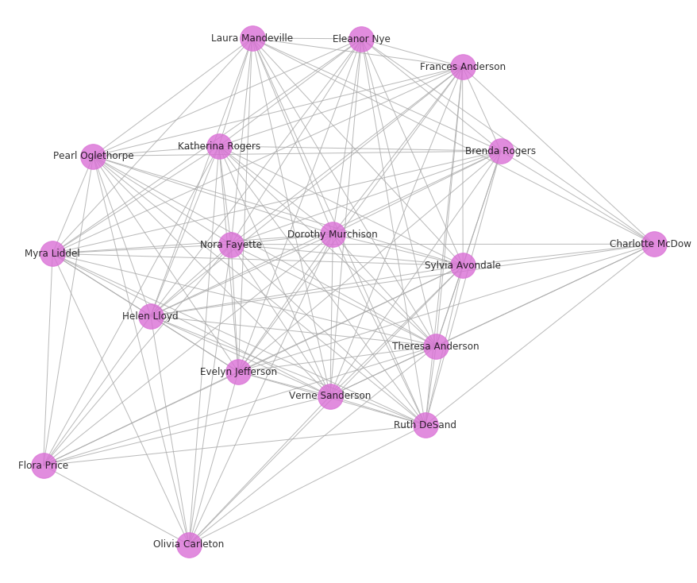

```python
nx.draw(W,with_labels=True, node_size=1000, node_color="orchid", font_size=12, font_family="calibri",
                edge_color="darkgray", alpha=0.8)
```

```python
# project bipartite graph onto women nodes keeping number of co-occurence
# the degree computed is weighted and counts the total number of shared contacts
W = bipartite.weighted_projected_graph(G, women)
print('')
print("#Friend meetings, Member")
for w in women:
    print('%d %s' % (W.degree(w, weight='weight'), w))
```

```
#Friend meetings, Member
50 Evelyn Jefferson
45 Laura Mandeville
57 Theresa Anderson
46 Brenda Rogers
24 Charlotte McDowd
32 Frances Anderson
36 Eleanor Nye
31 Pearl Oglethorpe
40 Ruth DeSand
38 Verne Sanderson
33 Myra Liddel
37 Katherina Rogers
46 Sylvia Avondale
43 Nora Fayette
34 Helen Lloyd
24 Dorothy Murchison
14 Olivia Carleton
14 Flora Price
```

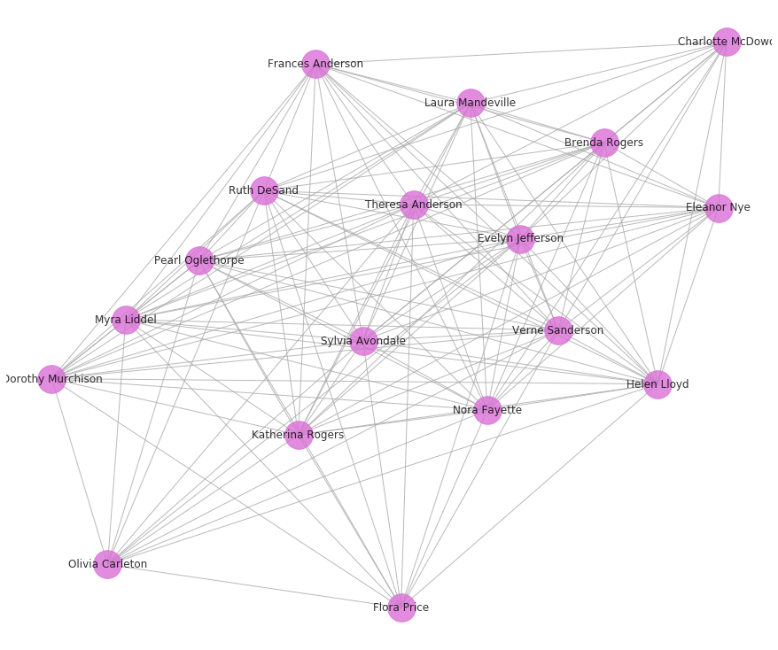

```python
nx.draw(W,with_labels=True, node_size=1000, node_color="orchid", font_size=12, font_family="calibri",
                edge_color="darkgray", alpha=0.8)
```

```python
# project bipartite graph onto club nodes
C = bipartite.projected_graph(G, clubs)
print('')
print("#Clubs")
for c in clubs:
    print('%d %s' % (C.degree(c), c))
```

```
#Clubs
8 E1
8 E2
8 E3
8 E4
8 E5
13 E6
13 E7
13 E8
13 E9
8 E10
8 E11
8 E12
8 E13
8 E14
```

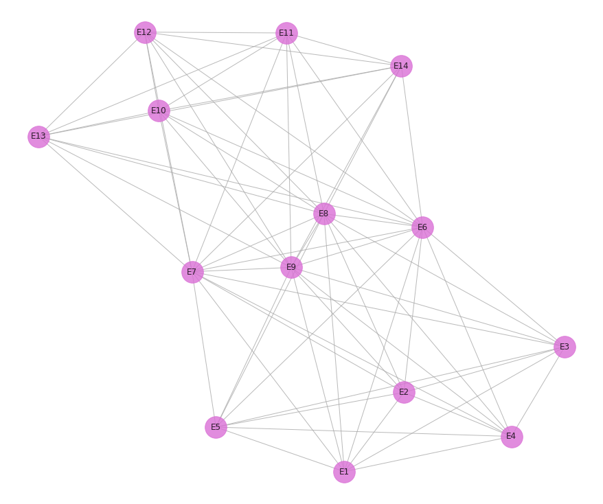

```python
nx.draw(C,with_labels=True, node_size=1000, node_color="orchid", font_size=12, font_family="calibri",
                edge_color="darkgray", alpha=0.8)
```

```python
# project bipartite graph onto women nodes keeping number of co-occurence
# the degree computed is weighted and counts the total number of shared contacts
C1 = bipartite.weighted_projected_graph(G, clubs)
print('')
print("#Club attendance, Clubs")
for c in clubs:
    print('%d %s' % (C1.degree(c, weight='weight'), c))
```

```
#Club attendance, Clubs
19 E1
20 E2
32 E3
23 E4
38 E5
41 E6
48 E7
59 E8
46 E9
25 E10
13 E11
28 E12
18 E13
18 E14
```

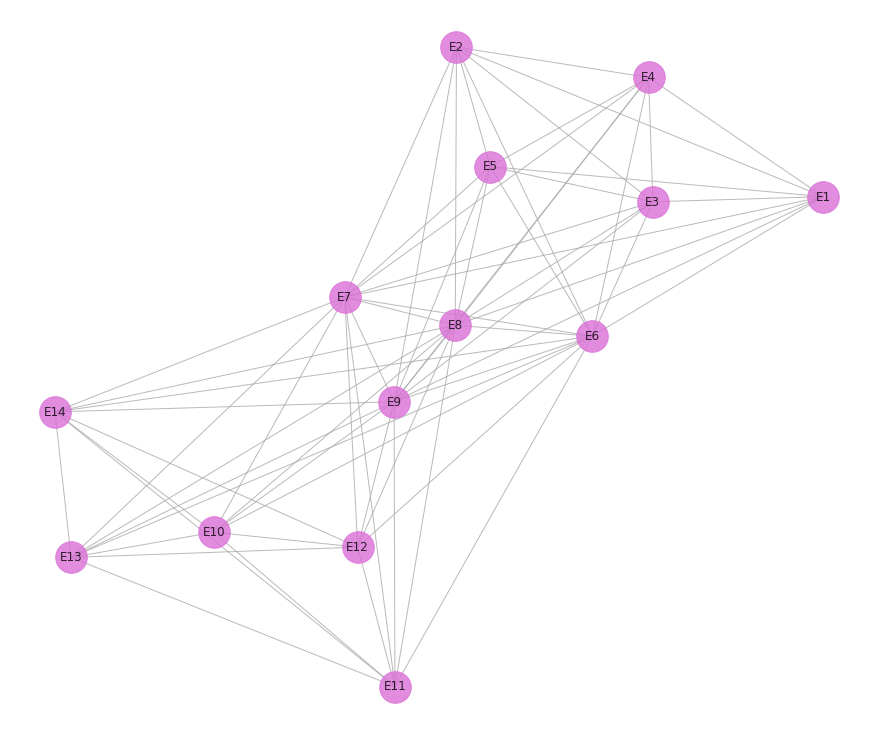

```python
nx.draw(C1,with_labels=True, node_size=1000, node_color="orchid", font_size=12, font_family="calibri",
                edge_color="darkgray", alpha=0.8)
```

```python
weights=[edata['weight'] for f,t,edata in W.edges(data=True)]
```

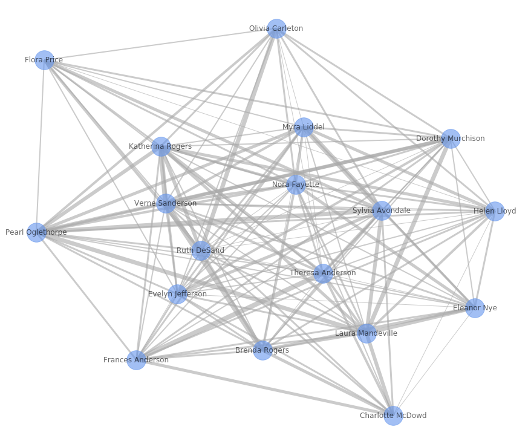

```python
nx.draw(W,width=weights, edge_color="darkgray", node_color="cornflowerblue", with_labels=True, node_size=1000, font_size=12, font_family="calibri",
                alpha=0.6)
```

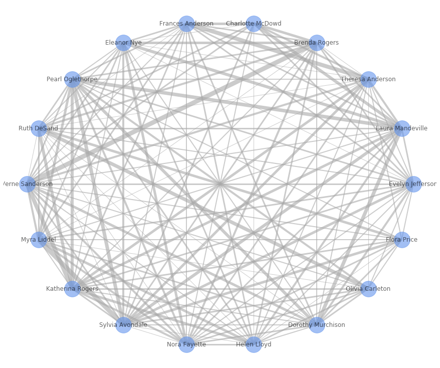

```python
nx.draw_circular(W,width=weights, edge_color="darkgray", node_color="cornflowerblue", with_labels=True, node_size=1000, font_size=12, font_family="calibri",
                alpha=0.6)
```

```python
weights=[edata['weight'] for f,t,edata in C1.edges(data=True)]
```

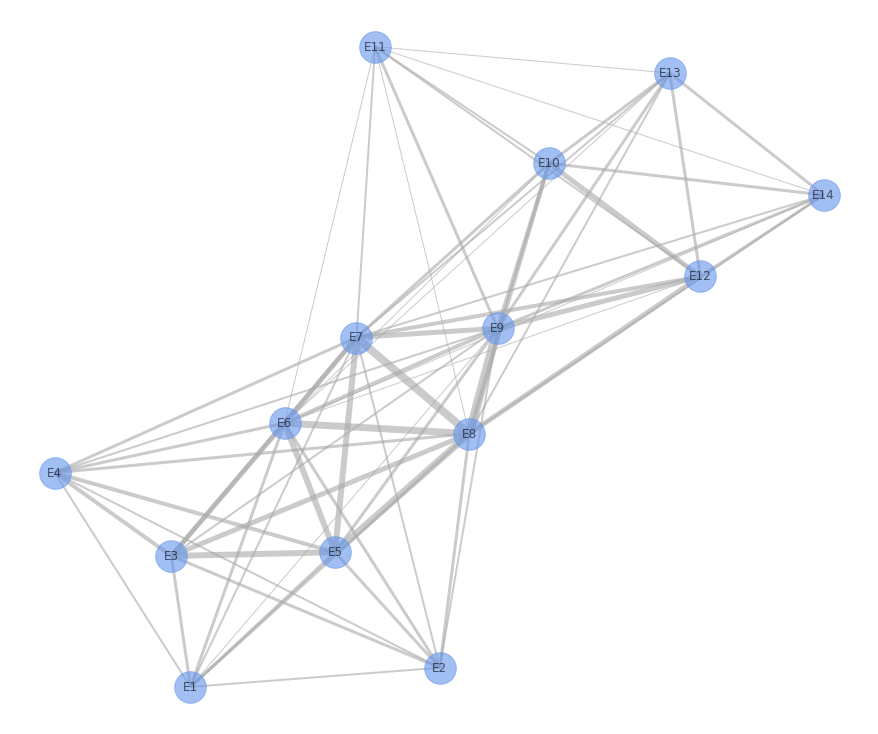

```python
nx.draw(C1,width=weights, edge_color="darkgray", node_color="cornflowerblue", with_labels=True, node_size=1000, font_size=12, font_family="calibri",
                alpha=0.6)
```

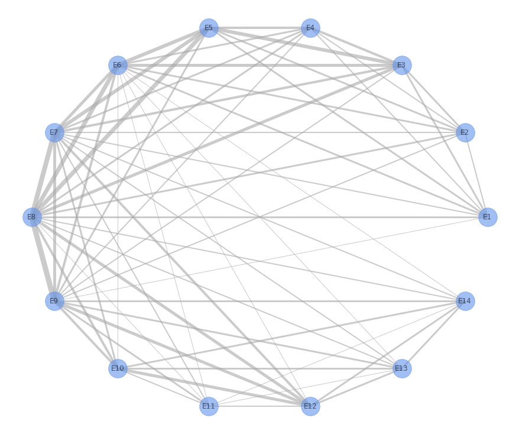

```python
nx.draw_circular(C1,width=weights, edge_color="darkgray", node_color="cornflowerblue", with_labels=True, node_size=1000, font_size=12, font_family="calibri",
                alpha=0.6)
```

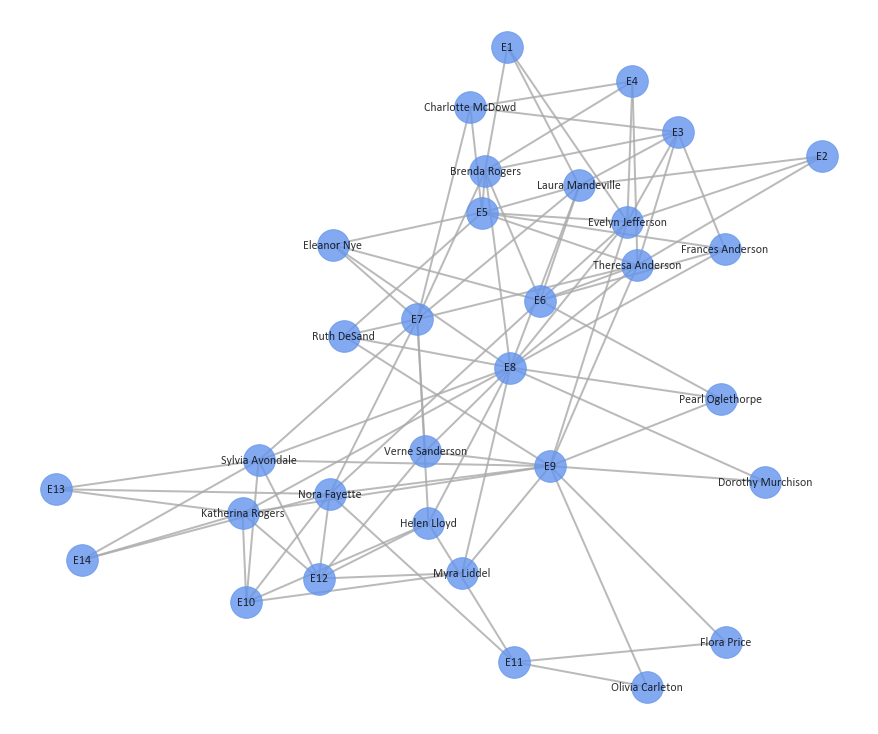

```python
nx.draw(G, with_labels=True, node_size=1000, node_color="cornflowerblue", font_size=12, font_family="calibri",
                 width=2, edge_color="darkgray", alpha=0.8)
```